# HW.Predict.2

Logan Hardy

03/16/2022

35 points (30 for this assignment, 5 for being on time)

# Importing Data

Import the life expectancy dataset. Make strings into factor variables.

```r
life_expectancy <- read_csv("../../Data/Life Expectancy Data.csv") %>% mutate_if(is.character, as.factor)
```

# Cleaning (4 points)

Make a copy of the dataset that has all large factors either combined or dropped, and that all factors have been made into numeric variables. You may also want to rename the Life expectancy column so you don’t run into errors with the space later on.

```r
# make a copy of the dataset without country.  Add underscore to Life_Expectancy and change Status to numeric
life_expectancy_copy <- life_expectancy %>% mutate("Life_Expectancy"=`Life expectancy`, Status = ifelse(Status == "Developed",0,1)) %>% select(-`Life expectancy`, -Country)
```

Make a new copy of the numeric dataset that has NAs removed.

```r
life_expectancy_no_nas <- life_expectancy_copy %>% na.omit()
```

# Correlation (4 points)

Make a correlation matrix, then visualize the data matrix with a corrplot and method of your choice. Adjust the aspect ratio so it is easier to read.

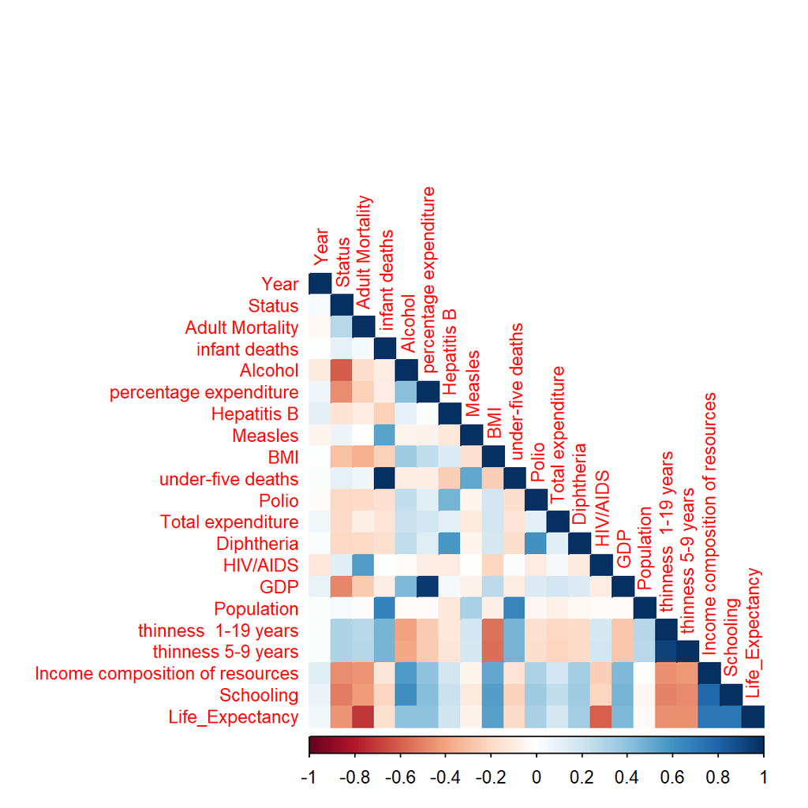

```r
corr_matrix <- cor(life_expectancy_no_nas)
corrplot(corr_matrix, method="color", type="lower", tl.cex = .8)
```

# Regression model (6 points)

Run a regression model with the data to predict life expectancy. Output a summary of the model.

```r
model <- lm(Life_Expectancy~., life_expectancy_no_nas)
summary(model)
```

```
##
## Call:
## lm(formula = Life_Expectancy ~ ., data = life_expectancy_no_nas)
##
## Residuals:
##      Min       1Q   Median       3Q      Max
## -16.7681  -2.1427   0.0273   2.1776  12.4242
##
## Coefficients:
##                                     Estimate Std. Error t value Pr(>|t|)
## (Intercept)                        3.090e+02  4.621e+01   6.687 3.12e-11 ***
## Year                              -1.272e-01  2.308e-02  -5.510 4.18e-08 ***
## Status                            -8.865e-01  3.353e-01  -2.644  0.00827 **
## `Adult Mortality`                 -1.621e-02  9.441e-04 -17.171  < 2e-16 ***
## `infant deaths`                    8.873e-02  1.059e-02   8.376  < 2e-16 ***
## Alcohol                           -1.313e-01  3.366e-02  -3.901 9.95e-05 ***
## `percentage expenditure`           3.026e-04  1.789e-04   1.691  0.09096 .
## `Hepatitis B`                     -3.258e-03  4.449e-03  -0.732  0.46413
## Measles                           -1.033e-05  1.070e-05  -0.966  0.33439
## BMI                                3.183e-02  5.955e-03   5.345 1.03e-07 ***
## `under-five deaths`               -6.662e-02  7.673e-03  -8.682  < 2e-16 ***
## Polio                              5.797e-03  5.121e-03   1.132  0.25776
## `Total expenditure`                9.220e-02  4.042e-02   2.281  0.02268 *
## Diphtheria                         1.403e-02  5.877e-03   2.387  0.01712 *
## `HIV/AIDS`                        -4.481e-01  1.780e-02 -25.174  < 2e-16 ***
## GDP                                2.451e-05  2.826e-05   0.867  0.38594
## Population                        -6.085e-10  1.733e-09  -0.351  0.72558
## `thinness  1-19 years`            -5.815e-03  5.254e-02  -0.111  0.91189
## `thinness 5-9 years`              -5.010e-02  5.185e-02  -0.966  0.33412
## `Income composition of resources`  1.045e+01  8.327e-01  12.549  < 2e-16 ***
## Schooling                          8.949e-01  5.910e-02  15.142  < 2e-16 ***
## ---
## Signif. codes:  0 '***' 0.001 '**' 0.01 '*' 0.05 '.' 0.1 ' ' 1
##
## Residual standard error: 3.556 on 1628 degrees of freedom
## Multiple R-squared:  0.8386, Adjusted R-squared:  0.8366
## F-statistic: 422.9 on 20 and 1628 DF,  p-value: < 2.2e-16
```

Q: What is the R and Adj R squared? What do these values represent?  
A: R-squared: 0.8386, Adjusted R-squared: 0.8366

Q: What is the coefficient of the HIV/Aids variable?  
A: -4.481e-01

Q: What is the p value of the population variable? Is this variable considered correlated based on what we discussed in class?  
A: 0.72558; No, population is not considered correlated because it has a high p-value and shows no correlation with Life_Expectancy in the correlation matrix

# Standardizing the dataset (2 points)

Create a standardized version of the dataset using min-max normalization. Print out the first row of this normalized dataset. Then output the summary of the model for this dataset.

```r
#normalize data to min/max scaler
normalize <- function(x) {
    return((x- min(x, na.rm = TRUE)) /(max(x, na.rm = TRUE)-min(x, na.rm = TRUE)))
}
min_max <- as.data.frame(lapply(life_expectancy_no_nas, normalize))

#print first row of normalized data
min_max %>% head(1)
```

```
##   Year Status Adult.Mortality infant.deaths Alcohol percentage.expenditure
## 1    1      1       0.3628809       0.03875       0            0.003759206
##   Hepatitis.B     Measles       BMI under.five.deaths   Polio Total.expenditure
## 1   0.6494845 0.008779605 0.2276964        0.03952381 0.03125         0.5435897
##   Diphtheria HIV.AIDS         GDP Population thinness..1.19.years
## 1  0.6494845        0 0.004888585 0.02607429            0.6309963
##   thinness.5.9.years Income.composition.of.resources Schooling Life_Expectancy
## 1          0.6120996                       0.5117521 0.3575758       0.4666667
```

```r
#create and output summary
model_min_max <- lm(Life_Expectancy~.,min_max)
summary(model_min_max)
```

```
##
## Call:
## lm(formula = Life_Expectancy ~ ., data = min_max)
##
## Residuals:
##      Min       1Q   Median       3Q      Max
## -0.37262 -0.04762  0.00061  0.04839  0.27609
##
## Coefficients:
##                                  Estimate Std. Error t value Pr(>|t|)
## (Intercept)                      0.322859   0.016713  19.318  < 2e-16 ***
## Year                            -0.042390   0.007694  -5.510 4.18e-08 ***
## Status                          -0.019700   0.007450  -2.644  0.00827 **
## Adult.Mortality                 -0.260092   0.015148 -17.171  < 2e-16 ***
## infant.deaths                    3.154940   0.376674   8.376  < 2e-16 ***
## Alcohol                         -0.052117   0.013358  -3.901 9.95e-05 ***
## percentage.expenditure           0.127494   0.075379   1.691  0.09096 .
## Hepatitis.B                     -0.007022   0.009589  -0.732  0.46413
## Measles                         -0.030177   0.031252  -0.966  0.33439
## BMI                              0.053119   0.009938   5.345 1.03e-07 ***
## under.five.deaths               -3.108802   0.358058  -8.682  < 2e-16 ***
## Polio                            0.012368   0.010925   1.132  0.25776
## Total.expenditure                0.027967   0.012261   2.281  0.02268 *
## Diphtheria                       0.030236   0.012669   2.387  0.01712 *
## HIV.AIDS                        -0.502817   0.019973 -25.174  < 2e-16 ***
## GDP                              0.064911   0.074849   0.867  0.38594
## Population                      -0.017495   0.049833  -0.351  0.72558
## thinness..1.19.years            -0.003502   0.031643  -0.111  0.91189
## thinness.5.9.years              -0.031282   0.032378  -0.966  0.33412
## Income.composition.of.resources  0.217353   0.017320  12.549  < 2e-16 ***
## Schooling                        0.328124   0.021670  15.142  < 2e-16 ***
## ---
## Signif. codes:  0 '***' 0.001 '**' 0.01 '*' 0.05 '.' 0.1 ' ' 1
##
## Residual standard error: 0.07902 on 1628 degrees of freedom
## Multiple R-squared:  0.8386, Adjusted R-squared:  0.8366
## F-statistic: 422.9 on 20 and 1628 DF,  p-value: < 2.2e-16
```

Q: Based on the coefficients, which variable is having the greatest effect on the y variable?  
A: infant.deaths

# Modeling

Now we are going to see if we can find a better model. Sometimes we can, sometimes we can’t.

## Imputing NAs (4 points)

Pick two imputing NA methods for this data. Then run the original clean (no NA) data, and these two new datasets into the lm_fun from the finisher file. (You will have to pull that function into this document.) Rbind these into a table of the R-Squared, Adjusted R-Squared, MAE, and RMSE.

```r
# Create the datasets

# Imputing with mean
impute_mean <- life_expectancy_copy %>%
  mutate(across(where(is.numeric), ~replace_na(.x, mean(.x, na.rm = TRUE))))

# Imputing with mode
calc_mode <- function(x){
  # List the distinct / unique values
  distinct_values <- unique(x)
  # Count the occurrence of each distinct value
  distinct_tabulate <- tabulate(match(x, distinct_values))
  # Return the value with the highest occurrence
  distinct_values[which.max(distinct_tabulate)]
}

# Since there isn't always a mode for numerical values, we will fill with the mode, then the median
impute_mode <- life_expectancy_copy %>%
  mutate(across(everything(), ~replace_na(.x, calc_mode(.x)))) %>%
  mutate(across(where(is.numeric), ~replace_na(.x, median(.x, na.rm = TRUE))))

#impute using kNN
impute_knn <- life_expectancy_copy %>% kNN(imp_var = FALSE)
```

```r
# Run the models and create a table
lm_fun <- function(df, y, results = TRUE) {
    model <- lm(as.formula(paste(y, "~.", collapse="")), df)
    results_vec <- c(round(summary(model)[["r.squared"]], 3),
                     round(summary(model)[["adj.r.squared"]], 3),
                     round(MAE(predict(model), df[[y]]), 3),
                     round(RMSE(predict(model), df[[y]]), 3))
    if (results) return(results_vec)
    else return(model)
}

life_expectancy_lm <- lm_fun(life_expectancy_no_nas, "Life_Expectancy")
impute_mean_lm <- lm_fun(impute_mean, "Life_Expectancy")
impute_mode_lm <- lm_fun(impute_mode, "Life_Expectancy")
impute_knn <- lm_fun(impute_knn, "Life_Expectancy")


model_results <-
  rbind(life_expectancy_lm,
        impute_mean_lm,
        impute_mode_lm,
        impute_knn)

colnames(model_results) <- c("R2", "Adj R2", "MAE", "RMSE")

model_results
```

```
##                       R2 Adj R2   MAE  RMSE
## life_expectancy_lm 0.839  0.837 2.715 3.533
## impute_mean_lm     0.820  0.819 3.011 4.036
## impute_mode_lm     0.820  0.819 3.010 4.034
## impute_knn         0.831  0.830 2.918 3.905
```

Q: Which model is best?  
A: life_expectancy_lm (eliminating NAs)

## Addressing Skewness (6 points)

From now on work with your data that has produced the best model. Check the skewness of your y variable both through the skewness function and through a histogram.

```r
moments::skewness(life_expectancy_no_nas$Life_Expectancy, na.rm = TRUE)
```

```
## [1] -0.628186
```

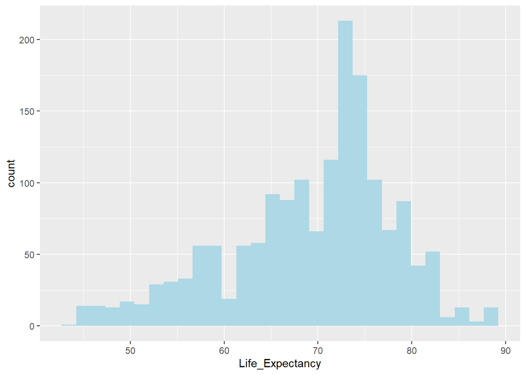

```r
life_expectancy_no_nas %>% ggplot(aes(x = Life_Expectancy)) + geom_histogram(fill ="lightblue")
```

Q: Is the y variable positive skewed, normally distributed, or negatively skewed?  
A: negatively skewed

Pick 3 skewness adjustments. Make a dataset and model for each, then bind them into the table that shows the results of past models.

```r
# Cubed y
no_nas_cubed_y <- life_expectancy_no_nas %>%
  mutate(y_cubed = Life_Expectancy^3) %>%
  select(-Life_Expectancy)

# Cubed_root y
no_nas_cube_root_y <- life_expectancy_no_nas %>%
  mutate(y_cube_root = Life_Expectancy^(1/3)) %>%
  select(-Life_Expectancy)

# Logarithmic y
no_nas_log_y <- life_expectancy_no_nas %>%
  mutate(y_log = log(Life_Expectancy)) %>%
  select(-Life_Expectancy)


cube_lm <- lm_fun(no_nas_cubed_y, "y_cubed")
cube_root_lm <- lm_fun(no_nas_cube_root_y, "y_cube_root")
log_lm <- lm_fun(no_nas_log_y, "y_log")

transformed_model_results <-
  rbind(model_results,
        cube_lm,
        cube_root_lm,
        log_lm)

colnames(transformed_model_results) <- c("R2", "Adj R2", "MAE", "RMSE")

transformed_model_results
```

```
##                       R2 Adj R2       MAE      RMSE
## life_expectancy_lm 0.839  0.837     2.715     3.533
## impute_mean_lm     0.820  0.819     3.011     4.036
## impute_mode_lm     0.820  0.819     3.010     4.034
## impute_knn         0.831  0.830     2.918     3.905
## cube_lm            0.812  0.810 40101.392 52125.655
## cube_root_lm       0.844  0.842     0.054     0.071
## log_lm             0.846  0.844     0.040     0.053
```

Q: Which model had the best results?  
A: log_lm (taking the log of the y-Life_Expectancy after all of the nas had been removed)

# Predicting (4 points)

Take your best dataset and run it through the lm_fun again, this time outputing the model instead of the results. Then create a random sample of two observations from your data (dropping the y of course!) and generate a prediction for them with a confidence interval. If you have created an adjustment, make sure you do the opposite adjustment so the predictions are readable.

(Opposite of ^2 is ^(1/2), Opposite of ^3 is ^(1/3), Opposite of log() is exp())

```r
log_model <- lm_fun(no_nas_log_y, "y_log", results = FALSE)

# Next we are going to create a hypothetical test county by grabbing a sample of 2 from the covid_clean_no_nas dataset. In real life, we would have a a whole dataset potentially of new counties we wanted to predict rates for. But this will work here.
life_expectancy_test <- sample_n(no_nas_log_y %>% select(!y_log), 2)

# Use the predict function with the log model to generate a prediction for these two observations.
predict(log_model, newdata = life_expectancy_test, interval = "confidence") %>% exp()
```

```
##        fit      lwr      upr
## 1 70.64811 69.99291 71.30944
## 2 73.41512 72.83884 73.99597
```

# Optional feedback:

How hard was this assignment? Was it: too hard, too easy, or just right?

ANSWER: Just right

Approximately how long did this assignment take you?

ANSWER: 2.5 hours